# Ejercicios tema 4

Isaac Subirana

Disseny. Curso: 17-18

## EJERCICIO 1

Un técnico agrónomo quiere comparar el efecto de 5 fuentes diferentes de nitrógeno en la producción de cebada junto con un control sin nitrógeno. Las 6 fuentes son:

1. A: (NH$_4$)SO$_4$
2. B: NH$_4$NO$_3$
3. C: CO(NH$_3$)$_2$
4. D: Ca(NO$_3$)$_2$
5. E: NaNO$_3$
6. F: Control

Como quería aplicar los tratamientos a un amplio rango de condiciones hizo un experimento con 4 tipus de suelo con un diseño en bloques aleatorizado.

Los datos son (tratamientos por filas y tipus de suelo por columnas):

|  | I | II | III | IV |
| --- | --- | --- | --- | --- |
| A | 32.1 | 35.6 | 41.9 | 35.4 |
| B | 30.1 | 31.5 | 37.1 | 30.8 |
| C | 25.4 | 27.4 | 33.8 | 31.1 |
| D | 24.1 | 33.0 | 35.6 | 31.4 |
| E | 26.1 | 31.0 | 33.8 | 31.9 |
| F | 23.1 | 24.8 | 26.7 | 26.7 |

Se pide:

## a) ¿Cómo se realizó el experimento? Haz una asignación concreta de los tratamientos a la unidades experimentales.

Se trata de un diseño de un factor (Tratamientos) en bloques (tipo de suelo) completamente aleatorizado. Dentro de cada bloque se seleccionaron 6 muestras y a cada una de ellas se le asignó un tratamiento al azar.

Tenemos un factor de efectos fijos (tratamiento) con seis niveles, y un factor bloque que es el tipo de suelo con 4 niveles. Ambos factores están cruzados y no tenemos réplicas..

- Modelo: $y_{ij} = \mu + \alpha_i + \beta_j + e_{ij}$, $i=1,\ldots,6$ tratamiento, $j=1,\ldots,4$ tipo de suelo
- Restricciones: $\sum_{i=1}^6 \alpha_i = 0$ i $\sum_{j=1}^4 \beta_j = 0$
- Suposiciones: $e_{ij} \sim N(0,\sigma)$ independientes

## b) Verifica si hay diferencias entre tratamientos

Tabla ANOVA

```r
y <- c(32.1, 35.6, 41.9, 35.4,
       30.1, 31.5, 37.1, 30.8,
       25.4, 27.4, 33.8, 31.1,
       24.1, 33.0, 35.6, 31.4,
       26.1, 31.0, 33.8, 31.9,
       23.1, 24.8, 26.7, 26.7)

tx <- rep(1:6, each=4)
suelo <- rep(1:4,6)
tx <- factor(tx, labels=LETTERS[1:6])
suelo <- factor(suelo, labels=c(c("I","II","III","IV")))

model <- aov(y ~ tx + suelo)

summary(model)
```

```
            Df Sum Sq Mean Sq F value   Pr(>F)
tx           5 256.38   51.28   17.42 8.95e-06 ***
suelo        3 193.36   64.45   21.89 9.81e-06 ***
Residuals   15  44.16    2.94
---
Signif. codes:  0 '***' 0.001 '**' 0.01 '*' 0.05 '.' 0.1 ' ' 1
```

El p-valor entre tratamientos es de 0.000008953149, y como es inferior a 0,05, rechazamos la hipótesis nula de igualdad entre tratamientos.

3. ¿Hay un tratamiento mejor?

Usamos el método de comparaciones múltiples de Tukey. En este problema el mejor tratamiento será el que dé una media más alta.

```r
library(agricolae)
HSD.test(model, "tx", console=TRUE)
```

```
Study: model ~ "tx"

HSD Test for y

Mean Square Error:  2.944

tx,  means

       y      std r  Min  Max
A 36.250 4.094305 4 32.1 41.9
B 32.375 3.201432 4 30.1 37.1
C 29.425 3.752666 4 25.4 33.8
D 31.025 4.930433 4 24.1 35.6
E 30.700 3.281260 4 26.1 33.8
F 25.325 1.732772 4 23.1 26.7

Alpha: 0.05 ; DF Error: 15
Critical Value of Studentized Range: 4.594735

Minimun Significant Difference: 3.941843

Treatments with the same letter are not significantly different.

       y groups
A 36.250      a
B 32.375     ab
D 31.025      b
E 30.700      b
C 29.425      b
F 25.325      c
```

Vemos como el tratamiento A es el mejor, pero no se distingue significativamente del B.

```r
library(agricolae)
LSD.test(model, "tract", console=TRUE)
```

```
Name:  tract
 tx suelo
```

## Pregunta extra. Valida el modelo

**Normalidad de los residuos**

Procedemos de la misma manera que con un factor

- Shapiro-Wilks

```r
residuos <- resid(model)
shapiro.test(residuos)
```

```
    Shapiro-Wilk normality test

data:  residuos
W = 0.97, p-value = 0.667
```

- QQ-plot

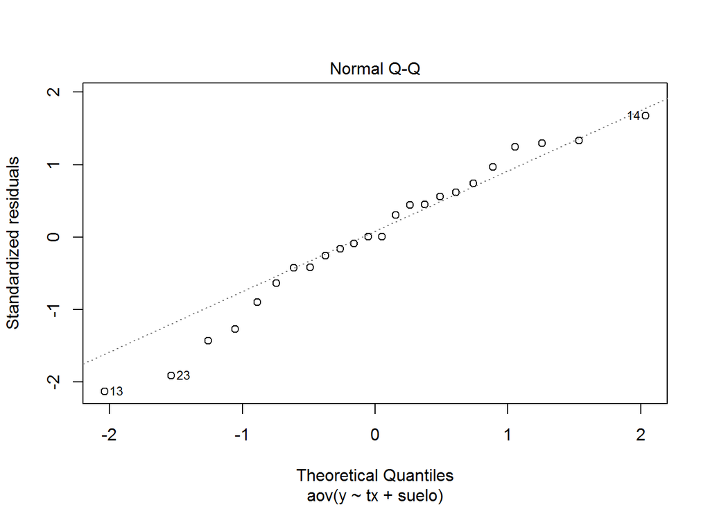

```r
plot(model, which=2)
```

Vemos como el test de Shapiro-wildks no és significativo (p-valor>0,05) y por lo tanto aceptamos la normalidad de los residuos. Además, los puntos del gráfico QQ no se encuentran lejos de la diagonal.

**Homogeneidad de varianzas**

- Test de Bartlett

No podemos realizar este test porque sólo tenemos un dato en cada combinación de tratamiento y bloque (condición experimental)

- Gráfico residuos vs valores esperados

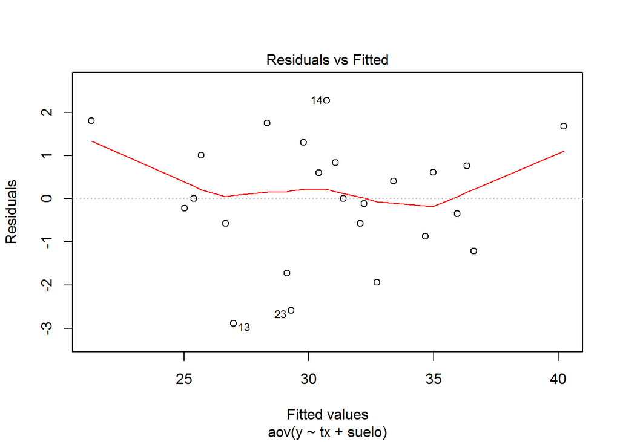

```r
plot(model, which=1)
```

Vemos como los puntos son bastante homogeneos. Por lo tanto podemos decir que sí hay homogeneidad de varianzas.

# EJERCICIO 2

Un ingeniero quiere verificar la resistencia a la presión de los aislantes de cerámica producidos con 4 mezclas de argila, A, B, C y D, y un control (E). Como sospecha que hay un gradiente de temperatura en el horno de cocción de las piezas de arriba a abajo y de delante a atrás, propone un diseño en cuadrado latino con las 5 filas, 5 columnas y 5 tratamientos.

Los datos obtenidos son:

|  | C1 | C2 | C3 | C4 | C5 |
| --- | --- | --- | --- | --- | --- |
| F1 | A: 33.8 | B: 33.7 | D. 30.4 | C: 32.7 | E: 24.4 |
| F2 | D: 37.0 | E: 28.8 | B: 33.5 | A: 34.6 | C: 33.4 |
| F3 | C: 35.8 | D: 35.6 | A: 36.9 | E: 26.7 | B: 35.1 |
| F4 | E: 33.2 | A: 37.1 | C: 27.4 | B: 38.1 | D: 34.1 |
| F5 | B: 34.8 | C: 29.1 | E: 32.7 | D: 37.4 | A: 36.4 |

Se pide

*Nota: se ha cambiado el orden de las preguntas*

## a) Verifica si hay diferencia entre los tratamientos (mezclas).

Tabla ANOVA.

```r
y <- c(33.8, 33.7, 30.4, 32.7, 24.4,
       37.0, 28.8, 33.5, 34.6, 33.4,
       35.8, 35.6, 36.9, 26.7, 35.1,
       33.2, 37.1, 27.4, 38.1, 34.1,
       34.8, 29.1, 32.7, 37.4, 36.4)

fila <- rep(1:5, each=5)
columna <- rep(1:5, 5)
mezcla <- c(1,2,3,4,5,
            4,5,2,1,3,
            3,4,1,5,2,
            5,1,3,2,4,
            2,3,5,4,1)
fila <- factor(fila, labels=c("F1","F2","F3","F4","F5"))
columna <- factor(columna, labels=c("C1","C2","C3","C4","C5"))
mezcla <- factor(mezcla, labels=LETTERS[1:5])

model <- aov(y ~ mezcla + fila + columna)

summary(model)
```

```
            Df Sum Sq Mean Sq F value  Pr(>F)
mezcla       4 173.94   43.49   5.810 0.00773 **
fila         4  34.52    8.63   1.153 0.37873
columna      4  16.70    4.17   0.558 0.69760
Residuals   12  89.82    7.48
---
Signif. codes:  0 '***' 0.001 '**' 0.01 '*' 0.05 '.' 0.1 ' ' 1
```

Hay diferencias significativas entre argilas ya que el p-valor es 0.007728109 < 0,05.

Podemos mirar qué mezcla ó mezclas son las mejores mediante métodos de comparaciones múltiples, como por ejemplo Tukey de la misma manera que con los diseños de un factor o de un factor con bloques.

```r
library(agricolae)
HSD.test(model, "mezcla", console=TRUE)
```

```
Study: model ~ "mezcla"

HSD Test for y

Mean Square Error:  7.484584

mezcla,  means

      y      std r  Min  Max
A 35.76 1.474110 5 33.8 37.1
B 35.04 1.843366 5 33.5 38.1
C 31.22 3.372240 5 27.4 35.8
D 35.36 1.973069 5 32.7 37.4
E 29.16 3.797762 5 24.4 33.2

Alpha: 0.05 ; DF Error: 12
Critical Value of Studentized Range: 4.50771

Minimun Significant Difference: 5.515118

Treatments with the same letter are not significantly different.

      y groups
A 35.76      a
D 35.36      a
B 35.04      a
C 31.22     ab
E 29.16      b
```

Las mejores mezclas son A, D y B, mientras que la C estaría a caballo de las tres anteriores y la E.

```r
library(agricolae)
LSD.test(model, "mezcla", console=TRUE)
```

```
Study: model ~ "mezcla"

LSD t Test for y

Mean Square Error:  7.484584

mezcla,  means and individual ( 95 %) CI

      y      std r      LCL      UCL  Min  Max
A 35.76 1.474110 5 33.09425 38.42575 33.8 37.1
B 35.04 1.843366 5 32.37425 37.70575 33.5 38.1
C 31.22 3.372240 5 28.55425 33.88575 27.4 35.8
D 35.36 1.973069 5 32.69425 38.02575 32.7 37.4
E 29.16 3.797762 5 26.49425 31.82575 24.4 33.2

Alpha: 0.05 ; DF Error: 12
Critical Value of t: 2.178813

least Significant Difference: 3.769934

Treatments with the same letter are not significantly different.

      y groups
A 35.76      a
D 35.36      a
B 35.04      a
C 31.22      b
E 29.16      b
```

Con el método LSD, se distinguen dos subgrupos homogéneos: A, D y B por un lado, y C y E por el otro.

## b) Haz otra asignación de los tratamientos a las filas y a las columnas.

Se trata de cambiar el orden de los tratamientso con el requisito que en ninguna fila y en ninguna columna se repita ningún tratamiento.

Una posibilidad sería la siguiente:

|  | C1 | C2 | C3 | C4 | C5 |
| --- | --- | --- | --- | --- | --- |
| F1 | A: 33.8 | B: 33.7 | C. 30.4 | D: 32.7 | E: 24.4 |
| F2 | B: 37.0 | C: 28.8 | D: 33.5 | E: 34.6 | A: 33.4 |
| F3 | C: 35.8 | D: 35.6 | E: 36.9 | A: 26.7 | B: 35.1 |
| F4 | D: 33.2 | E: 37.1 | A: 27.4 | B: 38.1 | C: 34.1 |
| F5 | E: 34.8 | A: 29.1 | B: 32.7 | C: 37.4 | D: 36.4 |

Podemos mirar la signfificación del tratamiento habiendo reordenado los tratamientos,

```r
mezcla.perm <- c(1, 2, 3, 4, 5,
                 2, 3, 4, 5, 1,
                 3, 4, 5, 1, 2,
                 4, 5, 1, 2, 3,
                 5, 1, 2, 3, 4)
mezcla.perm <- factor(mezcla.perm, labels=LETTERS[1:5])

model.perm <- aov(y ~ mezcla.perm + fila + columna)

summary(model.perm)
```

```
            Df Sum Sq Mean Sq F value Pr(>F)
mezcla.perm  4  77.38  19.346   1.297  0.326
fila         4  34.52   8.631   0.579  0.684
columna      4  24.08   6.021   0.404  0.803
Residuals   12 178.99  14.916
```

Vemos como ahora la mezcla deja de ser significativa. Este hecho no es de estrañar ya que en “permutar” los tratamientos “se rompe” la posible relación entre éste y la variable respuesta.

# Ejercicio 3

Se quiere evaluar la eficacia de 4 dosis diferentes de un fármaco contra la hipertensión arterial, junto con una dieta sin sal. Para ello, se seleccionan 25 individuos hipertensos que se distribuyen al azar de forma que tenemos 5, 4, 5, 6 y 5 individuos respectivamente en cada grupo. Al los del primer grupo no se les administra ninguna dosis (sólo dieta sin sal), y al resto de grupos se administran las diferentes dosis del fármaco (de forma creciente, es decir, el grupo 5 es el que toma una dosis más alta). Los resultados obtenidos de la presión arterial sistólica (PAS) al finalizar el periodo de tratamiento fueron:

| Tratamiento | Media | Desviación típica corregida |
| --- | --- | --- |
| 1 (dieta sin sal) | 178.20 | 3.96 |
| 2 (fármaco dosis 1) | 166.40 | 7.37 |
| 3 (fármaco dosis 2) | 164.60 | 5.27 |
| 4 (fármaco dosis 3) | 158.00 | 9.03 |
| 5 (fármaco dosis 4) | 151.40 | 6.65 |

## a) ¿Hay diferencias significativas entre utilizar una dieta sin sal y el fármaco? ¿Importa la dosis o no tiene importancia?

Se trata de un diseño de un factor fijo en que los datos se dan de forma agregada.

Entrada de datos

```r
n <- c(5, 4, 5, 6, 5)
medias <- c(178.2, 166.4, 164.6, 158, 151.4)
desvtcor <- c(3.96, 7.37, 5.27, 9.03, 6.65)
alpha <- 0.05
```

Cálculo de les estimaciones de los parámetros y los elementos de la tabla ANOVA

```r
varcor <- desvtcor^2 # variancia muestral corregida
mu <- sum(medias*n)/sum(n) # media general
alphas <- medias-mu # efectos de los grupos
SSgrupos <- sum(n*alphas^2)  # suma de cuadrados entre grupos
SSerror <- sum((n-1)*varcor) # suma de cuadrados del error
SStotal <- SSgrupos+SSerror # suma de cuadrados total
k <- length(n) # número de grupos
N <- sum(n) # total de datos
dfgrupos <- k-1 # grados de libertad de grupos
dferror <- N-k # grados de libertad de error
dftotal <- N-1 # grados de libertad total
MSgrupos <- SSgrupos/dfgrupos
MSerror <- SSerror/dferror
Fexp <- MSgrupos/MSerror
Fteorica <- qf(1-0.05, dfgrupos, dferror)
pvalor <- 1-pf(Fexp, dfgrupos, dferror)
```

[output not shown]

Como el pvalor es inferior a 0,05, diremos que sí que hay diferencias entre las distintas dosis y/o la dieta sin sal.

## b) ¿Qué fármaco o fármacos son los mejores (si es que hay alguno)?

**Con comparaciones múltiples**

```r
# en el mateix bucle calculo los diferentes métodos (Scheffé, Tukey, LSD):
compScheffe <- compTukey <- compLSD <- matrix("",k,k)
for (i in 1:(k-1)){
  for (j in (i+1):k){
    difer <- medias[i]-medias[j]
    SEdifer <- sqrt(MSerror*(1/n[i]+1/n[j]))
    vcScheffe <- sqrt((k-1)*qf(1-alpha,k,N-k))*SEdifer
    vcTukey <- (1/sqrt(2))*qtukey(1-alpha,k,N-k)*SEdifer
    vcLSD <- qt(1-alpha/2,N-k)*SEdifer
    compScheffe[i,j] <- paste(round(difer,1), if (abs(difer)>vcScheffe) "*" else "", sep="")
    compTukey[i,j] <- paste(round(difer,1), if (abs(difer)>vcTukey) "*" else "", sep="")
    compLSD[i,j] <- paste(round(difer,1), if (abs(difer)>vcLSD) "*" else "", sep="")
  }
}
niveles <- c("dieta sin sal","dosis 1","dosis 2","dosis 3","dosis 4")
rownames(compScheffe) <- rownames(compTukey) <- rownames(compLSD) <- niveles
colnames(compScheffe) <- colnames(compTukey) <- colnames(compLSD) <- niveles
compScheffe<-compScheffe[-k,-1]
compTukey<-compTukey[-k,-1]
compLSD<-compLSD[-k,-1]
```

### Scheffe

|  | dosis 1 | dosis 2 | dosis 3 | dosis 4 |
| --- | --- | --- | --- | --- |
| dieta sin sal | 11.8 | 13.6 | 20.2* | 26.8* |
| dosis 1 |  | 1.8 | 8.4 | 15* |
| dosis 2 |  |  | 6.6 | 13.2 |
| dosis 3 |  |  |  | 6.6 |

### Tukey

|  | dosis 1 | dosis 2 | dosis 3 | dosis 4 |
| --- | --- | --- | --- | --- |
| dieta sin sal | 11.8 | 13.6* | 20.2* | 26.8* |
| dosis 1 |  | 1.8 | 8.4 | 15* |
| dosis 2 |  |  | 6.6 | 13.2* |
| dosis 3 |  |  |  | 6.6 |

### LSD

|  | dosis 1 | dosis 2 | dosis 3 | dosis 4 |
| --- | --- | --- | --- | --- |
| dieta sin sal | 11.8* | 13.6* | 20.2* | 26.8* |
| dosis 1 |  | 1.8 | 8.4 | 15* |
| dosis 2 |  |  | 6.6 | 13.2* |
| dosis 3 |  |  |  | 6.6 |

Las comparaciones múltiples también se podrían resolver con la función `HSD.test` (ó `LSD.test`, `Scheffe.test`), de la manera siguiente:

```r
y <- rep(medias, n)
grupo <- rep(1:5, n)
HSD.test(y, grupo, DFerror=dferror, MSerror=MSerror, console=TRUE)
```

```
Study: y ~ grupo

HSD Test for y

Mean Square Error:  46.06816

grupo,  means

      y std r   Min   Max
1 178.2   0 5 178.2 178.2
2 166.4   0 4 166.4 166.4
3 164.6   0 5 164.6 164.6
4 158.0   0 6 158.0 158.0
5 151.4   0 5 151.4 151.4

Alpha: 0.05 ; DF Error: 20
Critical Value of Studentized Range: 4.231857

Groups according to probability of means differences and alpha level( 0.05 )

Treatments with the same letter are not significantly different.

      y groups
1 178.2      a
2 166.4     ab
3 164.6      b
4 158.0     bc
5 151.4      c
```

**Alternativa: Comparación entre la dieta y la media de las diferentes dosis:**

Contraste lineal: 1, -1/4, -1/4, -1/4, -1/4

```r
coefs <- c(1, -1/4, -1/4, -1/4, -1/4)
L <- sum(coefs*medias)
SSc <- L^2/sum(coefs^2/n)
MSc <- SSc/1
Fc <- MSc/MSerror
pvalor <- 1-pf(Fc,1,dferror)
c("F crítica"=Fc, "p-valor"=pvalor)
```

```
   F crítica      p-valor
2.832765e+01 3.290720e-05
```

Como el p-valor es < 0,05, rechazamos la hipótesis nula.

Recordad que la hipótesis que se contrasta es

$$\left\{\begin{array}{l}\text{H}_0:\quad 1\mu_1 + \frac{-1}{4}\mu_2 + \frac{-1}{4}\mu_3 + \frac{-1}{4}\mu_4 + \frac{-1}{4}\mu_5 = 0 \\
\text{H}_1:\quad 1\mu_1 + \frac{-1}{4}\mu_2 + \frac{-1}{4}\mu_3 + \frac{-1}{4}\mu_4 + \frac{-1}{4}\mu_5 \neq 0
\end{array}\right.$$

donde $\mu_1$, $\mu_2$, $\mu_3$, $\mu_4$ y $\mu_5$ son las medias poblacionales del control y de los diferentes fármacos respectivamente.